# DENETİMLİ MAKİNA ÖĞRENMESİ

## 3.2.Bagging ile sınıflandırma ağacı (BCT)

```r
if(!require("randomForest")){install.packages("randomForest")}
library(randomForest)
bag_class <- randomForest(as.factor(RingsInfant)~.-rings ,data=egitim_data2,mtry=8,importance=TRUE)
predict_bag_class <- predict(bag_class,newdata=test_data2)
table <- table(predict_bag_class ,RingsInfant_test)
table
```

```
##                  RingsInfant_test
## predict_bag_class Infant non-Infant
##        Infant        912        146
##        non-Infant     59        136
```

```r
accuracy_bag_test <- sum(diag(table))/sum(table)
accuracy_bag_test
```

```
## [1] 0.8363927
```

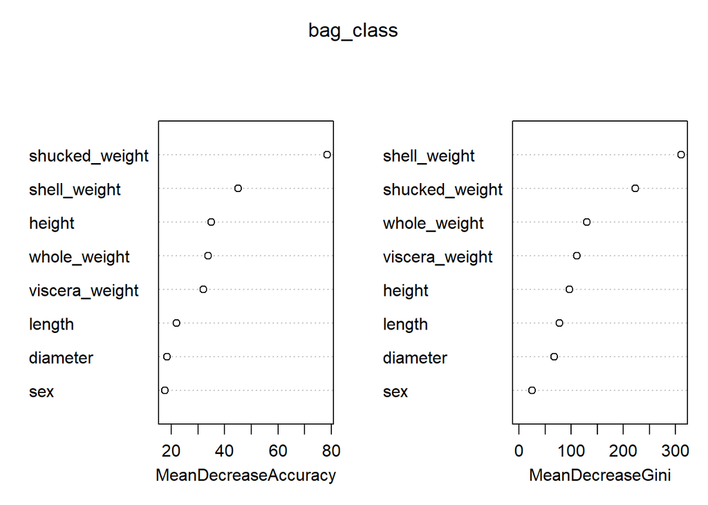

```r
#bag_class$importance
varImpPlot(bag_class)
```

Bagging ile sınıflandırmaya baktığımızda, mtry=8 aldık. Modelimizi eğitim verisinde kurup, testte accuraye baktığımızda, accuracy 0.84 bulduk. Sınıflandırma ağacına göre accuracy arttı. İmportance’lara baktığımızda shucked_weight değişkeni MeanDecreaseAccuracy anlamında en yüksek çıkmış. Gini anlamında ise shell_weight ön plana çıkmıştır.

## 3.3.Rassal Ormanlar ile Sınıflandırma Ağacı (RFC)

```r
rfc_class <- randomForest(as.factor(RingsInfant)~.-rings ,data=egitim_data2,mtry=3,importance=TRUE)
predict.rfc <- predict(rfc_class,newdata=test_data2)
table <- table(predict.rfc ,RingsInfant_test)
table
```

```
##             RingsInfant_test
## predict.rfc  Infant non-Infant
##   Infant        916        151
##   non-Infant     55        131
```

```r
accuracy_rfc_test <- sum(diag(table))/sum(table)
accuracy_rfc_test
```

```
## [1] 0.8355946
```

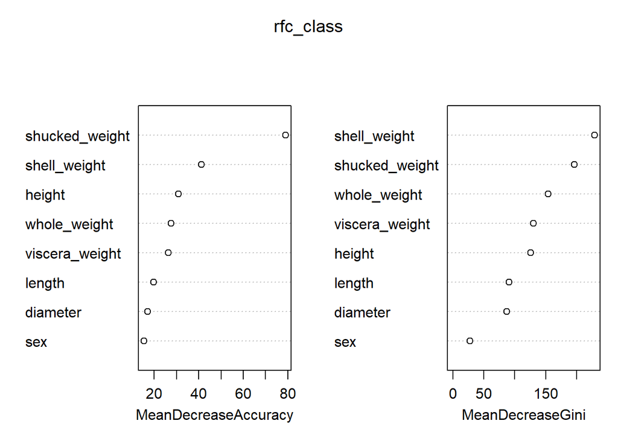

```r
#rfc_class$importance
varImpPlot(rfc_class)
```

Random forest sınıflandırmaya baktığımızda ise, bu sefer mtry=3 aldık. Bunun sebebi değişken sayısının karekökünü alıyor olmamız. Accuracy 0.84 çıktı. Gini endeksinde shell_weight değişkeni en yüksek çıkmıştır.